# Northern Elephant Seal: Post-Breeding PCA and Clustering

2026-10-27

# 1 Purpose and interpretation

This R Markdown document runs the revised Post-Breeding PCA and hierarchical clustering workflow. It is intended to live inside an R project and records the analysis choices and outputs alongside the code.

The workflow explores **k = 2–10** cluster solutions. It includes PCA diagnostics, cluster-size and silhouette summaries,bootstrap stability, sensitivity to the number of retained PCs, and a sensitivity analysis excluding isotope variables. Cluster profile tests are descriptive because the same variables are used to construct the clusters; they are not independent validation.

The analysis does not establish that clusters emerged during historical population recovery, demonstrate density-dependent competition, or independently identify prey. Those claims require evidence beyond contemporary isotope and tracking data.

# 2 Analysis

The chunk below contains the complete analysis pipeline. Outputs are written to the results and figures directories specified in the settings section.

# 3 =============================================================================

# 4 NESE_HCPC_PostBreeding_revised.R

# 5 Revised analysis pipeline addressing the Proceedings B reviewer comments

# 6

# 7 Main changes:

# 8 * Explicit variable names and ID checks (no fragile column-number indexing)

# 9 * No inconsistent varimax overwrite of PCA variable coordinates

# 10 * Reproducible PCA and clustering with saved settings/seeds

# 11 * Candidate k comparison using silhouette, bootstrap stability and cluster sizes

# 12 * Sensitivity analyses for number of PCs and exclusion of isotope variables

# 13 * Cluster profiles and adjusted exploratory tests, clearly separated from

# 14 independent validation

# 15 * No nicheROVER modelling of potentially undersized clusters by default

# 16 * No treating posterior draws as biological replicates

# 17

# 18 IMPORTANT:

# 19 1. Check DATA_FILE and OUTPUT_DIR for your project structure.

# 20 2. This script treats each row as one analysis unit. If TOPPID occurs more

# 21 than once in PostBreeding, resolve repeated trips/observations before

# 22 treating rows as independent. The script reports duplicates and stops

# 23 unless ALLOW_REPEATED_ROWS is explicitly changed to TRUE.

# 24 3. Review variable definitions and distribution/transformations before

# 25 interpreting cluster profiles.

# 26 =============================================================================

```r
set.seed(20261027)

# ------------------------------- USER SETTINGS -------------------------------
DATA_FILE <- "../data/f.PCAdata.1.rds"
OUTPUT_DIR <- "../results/PostBreeding_revised"
FIGURE_DIR <- "../figures/PostBreeding_revised"

ID_VAR <- "TOPPID"
TRIP_VAR <- "Trip"
TRIP_VALUE <- "PostBreeding"
YEAR_VAR <- "ProcedureYear"

# These are the 21 variables used by the original Post-Breeding PCA.
# Check these names against the source data and retain only variables justified
# by the study question. Variables are scaled before PCA.
ANALYSIS_VARS <- c(
  "d13C", "d15N",
  "MaxLat_degrees", "MinLon_degrees",
  "MedianDistToContShelf_km", "SdDistContShelf_km",
  "MesoEcoProportionShelf", "MesoEcoProportionCAC",
  "MesoEcoProportionSubArcticPac", "MesoEcoProportionNorthCPac",
  "Mean_Depth_m", "Mean_Depth_sd",
  "Mean_Duration_sec", "Mean_Duration_sd",
  "Pct_TransitDives", "Pct_ForagingDives", "Pct_DriftDives",
  "Pct_BenthicDives", "PctTripDiving",
  "DeepDayForageDivesMedian_m", "DeepNightForageDivesMedian_m"
)
ISOTOPE_VARS <- c("d13C", "d15N")

# Explore a broad range of cluster numbers without privileging previous results.
# Inspect k = 2 through 10; choose the final solution only after reviewing all
# diagnostics, cluster sizes, sensitivity analyses and ecological interpretability.
K_CANDIDATES <- 2:10
PC_CANDIDATES <- 2:10
BOOTSTRAP_REPS <- 500
MIN_CLUSTER_N <- 10
ALLOW_REPEATED_ROWS <- FALSE

# Clustering method for primary solution
HC_METHOD <- "ward.D2"

# ------------------------------ SET UP OUTPUTS -------------------------------
dir.create(OUTPUT_DIR, recursive = TRUE, showWarnings = FALSE)
dir.create(FIGURE_DIR, recursive = TRUE, showWarnings = FALSE)

required_packages <- c("dplyr", "ggplot2", "cluster", "factoextra", "FactoMineR",
                       "fpc", "mclust", "readr", "tibble", "tidyr")
missing_packages <- required_packages[
  !vapply(required_packages, requireNamespace, logical(1), quietly = TRUE)
]
if (length(missing_packages)) {
  stop("Install required packages first: ",
       paste(missing_packages, collapse = ", "))
}

suppressPackageStartupMessages({
  library(dplyr)
  library(ggplot2)
  library(cluster)
  library(factoextra)
  library(FactoMineR)
  library(fpc)
  library(mclust)
  library(readr)
  library(tibble)
})

# -------------------------------- LOAD DATA -----------------------------------
if (!file.exists(DATA_FILE)) {
  stop("Cannot find DATA_FILE: ", DATA_FILE,
       "\nChange DATA_FILE at the top of this script.")
}
raw_data <- readRDS(DATA_FILE)
```

```r
needed_columns <- unique(c(ID_VAR, TRIP_VAR, YEAR_VAR, ANALYSIS_VARS))
missing_columns <- setdiff(needed_columns, names(raw_data))
if (length(missing_columns)) {
  stop("These required columns are missing from the RDS file: ",
       paste(missing_columns, collapse = ", "))
}

pb <- raw_data %>%
  dplyr::filter(.data[[TRIP_VAR]] == TRIP_VALUE) %>%
  dplyr::mutate(.row_id = dplyr::row_number())

if (nrow(pb) == 0) stop("No rows found for Trip == '", TRIP_VALUE, "'.")

# Stable row identity: preserve the original individual ID and create a unique
# row ID for analysis/output. Repeated individuals must be addressed explicitly.
duplicate_ids <- pb %>%
  dplyr::count(.data[[ID_VAR]], name = "n_rows") %>%
  dplyr::filter(n_rows > 1)

write_csv(duplicate_ids, file.path(OUTPUT_DIR, "repeated_IDs_check.csv"))

if (nrow(duplicate_ids) > 0 && !ALLOW_REPEATED_ROWS) {
  stop(
    "Repeated TOPPID values were found in the Post-Breeding subset. ",
    "See repeated_IDs_check.csv. Do not treat multiple trips from the same ",
    "seal as independent without a justified approach. Resolve the sampling ",
    "unit first, or set ALLOW_REPEATED_ROWS <- TRUE only after documenting ",
    "why repeated rows are appropriate for this analysis."
  )
}
```

```r
# Convert candidate variables to numeric and remove rows with missing/nonfinite
# values for any selected analysis variable. The excluded rows are recorded.
for (v in ANALYSIS_VARS) {
  if (!is.numeric(pb[[v]])) {
    suppressWarnings(pb[[v]] <- as.numeric(as.character(pb[[v]])))
  }
}
valid_rows <- complete.cases(pb[, ANALYSIS_VARS, drop = FALSE]) &
  apply(pb[, ANALYSIS_VARS, drop = FALSE], 1, function(z) all(is.finite(z)))
excluded <- pb[!valid_rows, c(ID_VAR, ".row_id"), drop = FALSE]
write_csv(excluded, file.path(OUTPUT_DIR, "rows_excluded_missing_or_nonfinite.csv"))
pb <- pb[valid_rows, , drop = FALSE]

if (nrow(pb) < max(K_CANDIDATES) + 2) stop("Too few complete rows for clustering.")
if (any(vapply(pb[, ANALYSIS_VARS, drop = FALSE], sd, numeric(1)) == 0)) {
  zero_var <- names(pb[, ANALYSIS_VARS, drop = FALSE])[
    vapply(pb[, ANALYSIS_VARS, drop = FALSE], sd, numeric(1)) == 0
  ]
  stop("Zero-variance variables must be removed: ", paste(zero_var, collapse = ", "))
}

write_csv(
  data.frame(
    n_rows_input = nrow(raw_data %>% dplyr::filter(.data[[TRIP_VAR]] == TRIP_VALUE)),
    n_rows_analysed = nrow(pb),
    n_unique_IDs = dplyr::n_distinct(pb[[ID_VAR]]),
    n_rows_excluded = nrow(excluded),
    variables = length(ANALYSIS_VARS)
  ),
  file.path(OUTPUT_DIR, "sample_size_summary.csv")
)
```

```r
# Summarise year representation; temporal effects are not automatically
# controlled by unsupervised clustering and should be examined downstream.
if (YEAR_VAR %in% names(pb)) {
  year_summary <- pb %>%
    dplyr::count(.data[[YEAR_VAR]], name = "n_rows")
  write_csv(year_summary, file.path(OUTPUT_DIR, "sample_size_by_year.csv"))
}

# ----------------------------- CORE FUNCTIONS --------------------------------
run_pca <- function(dat, vars, n_pc) {
  x <- scale(dat[, vars, drop = FALSE], center = TRUE, scale = TRUE)
  pca <- prcomp(x, center = FALSE, scale. = FALSE)
  n_pc <- min(n_pc, ncol(pca$x), nrow(pca$x) - 1)
  scores <- as.data.frame(pca$x[, seq_len(n_pc), drop = FALSE])
  names(scores) <- paste0("PC", seq_len(n_pc))
  list(pca = pca, scores = scores, x = x, n_pc = n_pc)
}

cluster_once <- function(scores, k, method = HC_METHOD) {
  d <- dist(scores)
  hc <- hclust(d, method = method)
  cl <- cutree(hc, k = k)
  list(hc = hc, cluster = cl, silhouette = mean(cluster::silhouette(cl, d)[, "sil_width"]))
}

# Bootstrap stability via fpc::clusterboot. Average Jaccard values indicate
# how reproducibly each cluster is recovered under resampling; these are not
# evidence by themselves that groups are biologically discrete.
cluster_stability <- function(scores, k, B = BOOTSTRAP_REPS) {
  set.seed(20261027 + k + ncol(scores))
  cb <- tryCatch(
    fpc::clusterboot(
      scores,
      B = B,
      bootmethod = "boot",
      clustermethod = fpc::hclustCBI,
      method = HC_METHOD,
      k = k,
      count = FALSE,
      seed = 20261027 + k + ncol(scores)
    ),
    error = function(e) {
      warning("clusterboot failed for k=", k, ": ", conditionMessage(e))
      NULL
    }
  )
  if (is.null(cb)) {
    return(list(mean_jaccard = NA_real_, cluster_jaccard = NA_character_))
  }
  jac <- cb$bootmean
  list(
    mean_jaccard = mean(jac, na.rm = TRUE),
    cluster_jaccard = paste(round(jac, 3), collapse = ";")
  )
}

fit_partition <- function(dat, vars, n_pc, k, label) {
  p <- run_pca(dat, vars, n_pc)
  scores <- p$scores
  fit <- cluster_once(scores, k)
  cl <- factor(fit$cluster, levels = seq_len(k),
               labels = paste0("Cluster ", seq_len(k)))
  sizes <- as.data.frame(table(cl), stringsAsFactors = FALSE)
  names(sizes) <- c("cluster", "n")
  stab <- cluster_stability(scores, k)
  list(
    label = label, vars = vars, n_pc = p$n_pc, k = k,
    pca = p$pca, scores = scores, hc = fit$hc,
    cluster = cl, silhouette = fit$silhouette,
    stability = stab, sizes = sizes
  )
}
```

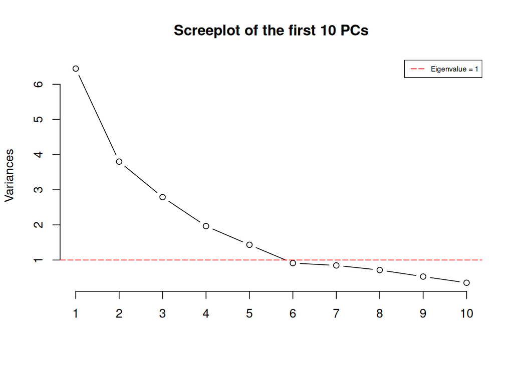

```r
# ---------------------------- PRIMARY PCA ------------------------------------
pca_full <- run_pca(pb, ANALYSIS_VARS, max(PC_CANDIDATES))
pca_summary <- data.frame(
  PC = seq_along(pca_full$pca$sdev),
  eigenvalue = pca_full$pca$sdev^2,
  variance_explained = (pca_full$pca$sdev^2) / sum(pca_full$pca$sdev^2),
  cumulative_variance = cumsum((pca_full$pca$sdev^2) / sum(pca_full$pca$sdev^2))
)
write_csv(pca_summary, file.path(OUTPUT_DIR, "PCA_variance_full.csv"))
write_csv(
  data.frame(variable = rownames(pca_full$pca$rotation),
             pca_full$pca$rotation, check.names = FALSE),
  file.path(OUTPUT_DIR, "PCA_loadings_full.csv")
)

#Screeplot
n_scree <- min(10, length(pca_full$pca$sdev))

screeplot(
  pca_full$pca,
  type = "l",
  npcs = n_scree,
  main = paste("Screeplot of the first", n_scree, "PCs")
)
abline(h = 1, col="red", lty=5)
legend("topright", legend=c("Eigenvalue = 1"),
       col=c("red"), lty=5, cex=0.6)
```

```r
p_var <- ggplot(pca_summary, aes(x = PC, y = cumulative_variance)) +
  geom_line() + geom_point() +
  scale_x_continuous(breaks = pca_summary$PC) +
  labs(x = "Principal component", y = "Cumulative variance explained",
       title = "Post-Breeding PCA: cumulative variance") +
  theme_minimal()
ggsave(file.path(FIGURE_DIR, "PCA_cumulative_variance.pdf"), p_var,
       width = 7, height = 5)
```

```r
# ------------------------- COMPARE k AND PC COUNTS ----------------------------
diagnostic_rows <- list()
fit_objects <- list()
counter <- 1L
PC_CANDIDATES <- c(4,5,6)

for (npc in PC_CANDIDATES) {
  if (npc >= ncol(pca_full$pca$x)) next
  for (k in K_CANDIDATES) {
    fit <- fit_partition(pb, ANALYSIS_VARS, npc, k,
                         label = paste0("full_PC", npc, "_k", k))
    fit_objects[[fit$label]] <- fit
    diagnostic_rows[[counter]] <- data.frame(
      analysis = "full", n_PC = npc, k = k,
      cumulative_variance = pca_summary$cumulative_variance[npc],
      mean_silhouette = fit$silhouette,
      mean_bootstrap_jaccard = fit$stability$mean_jaccard,
      cluster_jaccard = fit$stability$cluster_jaccard,
      minimum_cluster_n = min(as.numeric(fit$sizes$n)),
      cluster_sizes = paste(fit$sizes$n, collapse = ";")
    )
    counter <- counter + 1L
  }
}
diagnostics <- dplyr::bind_rows(diagnostic_rows)
write_csv(diagnostics, file.path(OUTPUT_DIR, "k_PC_sensitivity_diagnostics.csv"))
```

```r
# Plot diagnostics; do not select k using a single metric alone.
p_sil <- ggplot(diagnostics, aes(x = factor(k), y = mean_silhouette,
                                 group = factor(n_PC), colour = factor(n_PC))) +
  geom_point() + geom_line() +
  labs(x = "Number of clusters (k)", y = "Mean silhouette width",
       colour = "Number of PCs", title = "Post-Breeding cluster diagnostics") +
  theme_minimal()
ggsave(file.path(FIGURE_DIR, "cluster_silhouette_by_k_PC.pdf"), p_sil,
       width = 7, height = 5)
```

```r
# ----------------------- ISOTOPE-EXCLUSION SENSITIVITY ------------------------
BEHAVIOURAL_VARS <- setdiff(ANALYSIS_VARS, ISOTOPE_VARS)
if (length(BEHAVIOURAL_VARS) < 2) stop("Too few variables for isotope-exclusion analysis.")

isotope_sensitivity <- list()
counter <- 1L
for (npc in PC_CANDIDATES) {
  for (k in K_CANDIDATES) {
    fit_full <- fit_partition(pb, ANALYSIS_VARS, npc, k,
                              label = paste0("full_PC", npc, "_k", k))
    fit_noiso <- fit_partition(pb, BEHAVIOURAL_VARS, npc, k,
                               label = paste0("no_isotopes_PC", npc, "_k", k))
    ari <- mclust::adjustedRandIndex(as.integer(fit_full$cluster),
                                     as.integer(fit_noiso$cluster))
    isotope_sensitivity[[counter]] <- data.frame(
      n_PC = npc, k = k,
      ARI_full_vs_no_isotopes = ari,
      silhouette_full = fit_full$silhouette,
      silhouette_no_isotopes = fit_noiso$silhouette,
      stability_full = fit_full$stability$mean_jaccard,
      stability_no_isotopes = fit_noiso$stability$mean_jaccard,
      min_cluster_n_full = min(as.numeric(fit_full$sizes$n)),
      min_cluster_n_no_isotopes = min(as.numeric(fit_noiso$sizes$n)),
      sizes_full = paste(fit_full$sizes$n, collapse = ";"),
      sizes_no_isotopes = paste(fit_noiso$sizes$n, collapse = ";")
    )
    counter <- counter + 1L
  }
}
isotope_sensitivity <- dplyr::bind_rows(isotope_sensitivity)
write_csv(isotope_sensitivity,
          file.path(OUTPUT_DIR, "isotope_exclusion_sensitivity.csv"))
```

```r
# ------------------------- CHOOSE FINAL SOLUTION ------------------------------
#Review diagnostics, minimum sizes, stability,
# isotope sensitivity, year structure and ecological interpretability before
# setting FINAL_N_PC and FINAL_K below.
FINAL_N_PC <- 4
FINAL_K <- 4

if (!FINAL_N_PC %in% PC_CANDIDATES) {
  stop("FINAL_N_PC must be one of PC_CANDIDATES.")
}
if (!FINAL_K %in% K_CANDIDATES) {
  stop("FINAL_K must be one of K_CANDIDATES.")
}

final_fit <- fit_partition(pb, ANALYSIS_VARS, FINAL_N_PC, FINAL_K,
                           label = "final_full")
pb_final <- pb %>%
  dplyr::mutate(cluster = final_fit$cluster)

# Save cluster assignments joined to the original data. Row order is preserved.
write_csv(pb_final, file.path(OUTPUT_DIR, "PB_Clusters_revised.csv"))
saveRDS(final_fit$pca, file.path(OUTPUT_DIR, "PCA_final.rds"))
saveRDS(final_fit$hc, file.path(OUTPUT_DIR, "HCPC_hclust_final.rds"))
write_csv(
  data.frame(
    ID = pb_final[[ID_VAR]],
    row_id = pb_final$.row_id,
    cluster = as.character(final_fit$cluster),
    final_n_PC = FINAL_N_PC,
    final_k = FINAL_K
  ),
  file.path(OUTPUT_DIR, "final_cluster_assignments.csv")
)

# Dendrogram and PCA score plot (first two retained PCs).
pdf(file.path(FIGURE_DIR, "final_dendrogram.pdf"), width = 9, height = 6)
plot(final_fit$hc, labels = FALSE,
     main = paste0("Post-Breeding hierarchical clustering (k = ", FINAL_K, ")"),
     xlab = "", sub = "")
rect.hclust(final_fit$hc, k = FINAL_K, border = seq_len(FINAL_K) + 1)
dev.off()
```

```r
score_plot_data <- cbind(
  pb_final[, c(ID_VAR, YEAR_VAR), drop = FALSE],
  final_fit$scores,
  cluster = final_fit$cluster
)
p_scores <- ggplot(score_plot_data,
                   aes(x = PC1, y = PC2, colour = cluster)) +
  geom_point(size = 2, alpha = 0.8) +
  labs(title = "Post-Breeding PCA scores by selected cluster",
       subtitle = paste0(FINAL_N_PC, " PCs used for clustering; plot shows first two"),
       colour = "Cluster") +
  theme_minimal()
ggsave(file.path(FIGURE_DIR, "final_PCA_scores_by_cluster.pdf"), p_scores,
       width = 7, height = 5)
```

```r
# --------------------------- CLUSTER PROFILES --------------------------------
# Descriptive summaries are used to interpret cluster profiles, not to claim
# independent validation. Report n and uncertainty, not only p-values.
profile_long <- pb_final %>%
  dplyr::select(cluster, dplyr::all_of(ANALYSIS_VARS)) %>%
  tidyr::pivot_longer(cols = dplyr::all_of(ANALYSIS_VARS),
                      names_to = "variable", values_to = "value") %>%
  dplyr::group_by(cluster, variable) %>%
  dplyr::summarise(
    n = sum(is.finite(value)),
    mean = mean(value, na.rm = TRUE),
    sd = sd(value, na.rm = TRUE),
    median = median(value, na.rm = TRUE),
    q25 = quantile(value, 0.25, na.rm = TRUE),
    q75 = quantile(value, 0.75, na.rm = TRUE),
    .groups = "drop"
  )
write_csv(profile_long, file.path(OUTPUT_DIR, "cluster_profiles_long.csv"))

cluster_sizes <- pb_final %>%
  dplyr::count(cluster, name = "n") %>%
  dplyr::mutate(proportion = n / sum(n),
                below_minimum = n < MIN_CLUSTER_N)
write_csv(cluster_sizes, file.path(OUTPUT_DIR, "final_cluster_sizes.csv"))
```

```r
# Exploratory Kruskal-Wallis tests per variable with Benjamini-Hochberg
# correction. These describe association with the clusters defined using these
# same variables; they are NOT independent validation tests.
exploratory_tests <- lapply(ANALYSIS_VARS, function(v) {
  dd <- pb_final[, c("cluster", v), drop = FALSE]
  names(dd) <- c("cluster", "value")
  dd <- dd[is.finite(dd$value) & !is.na(dd$cluster), , drop = FALSE]
  if (length(unique(dd$cluster)) < 2) {
    return(data.frame(variable = v, statistic = NA_real_, p = NA_real_))
  }
  test <- tryCatch(stats::kruskal.test(value ~ cluster, data = dd),
                   error = function(e) NULL)
  if (is.null(test)) {
    data.frame(variable = v, statistic = NA_real_, p = NA_real_)
  } else {
    data.frame(variable = v, statistic = unname(test$statistic),
               p = test$p.value)
  }
})
exploratory_tests <- dplyr::bind_rows(exploratory_tests) %>%
  dplyr::mutate(p_BH = p.adjust(p, method = "BH"))
write_csv(exploratory_tests,
          file.path(OUTPUT_DIR, "exploratory_cluster_profile_tests.csv"))

# Faceted descriptive distributions, with individual observations shown.
plot_data <- pb_final %>%
  dplyr::select(cluster, dplyr::all_of(ANALYSIS_VARS)) %>%
  tidyr::pivot_longer(cols = dplyr::all_of(ANALYSIS_VARS),
                      names_to = "variable", values_to = "value")
p_profiles <- ggplot(plot_data, aes(x = cluster, y = value, colour = cluster)) +
  geom_boxplot(outlier.shape = NA, alpha = 0.25) +
  geom_jitter(width = 0.12, alpha = 0.45, size = 0.8) +
  facet_wrap(~ variable, scales = "free_y") +
  labs(title = "Post-Breeding cluster profiles",
       subtitle = "Descriptive plots; clusters were constructed using these variables",
       x = "Cluster", y = "Observed value") +
  theme_minimal() +
  theme(legend.position = "none",
        axis.text.x = element_text(angle = 45, hjust = 1))
ggsave(file.path(FIGURE_DIR, "cluster_profiles_all_variables.pdf"),
       p_profiles, width = 13, height = 10)
```

```r
# ----------------------------- YEAR STRUCTURE --------------------------------
# Cluster-year association is a diagnostic, not a causal test. If trips span
# years unevenly, report this and consider year effects in subsequent models.
if (YEAR_VAR %in% names(pb_final)) {
  year_tab <- table(pb_final$cluster, pb_final[[YEAR_VAR]], useNA = "ifany")
  write.csv(as.data.frame.matrix(year_tab),
            file.path(OUTPUT_DIR, "cluster_by_year_counts.csv"))
  if (all(rowSums(year_tab) > 0) && all(colSums(year_tab) > 0)) {
    year_test <- tryCatch(chisq.test(year_tab), error = function(e) NULL)
    if (!is.null(year_test)) {
      capture.output(year_test,
                     file = file.path(OUTPUT_DIR, "cluster_by_year_chisq.txt"))
    }
  }
}

# ------------------------------- AUDIT REPORT ---------------------------------
capture.output(sessionInfo(),
               file = file.path(OUTPUT_DIR, "sessionInfo.txt"))
writeLines(
  c(
    "Post-Breeding revised clustering analysis",
    paste("Input:", normalizePath(DATA_FILE, mustWork = FALSE)),
    paste("Trip subset:", TRIP_VALUE),
    paste("Rows analysed:", nrow(pb_final)),
    paste("Unique IDs:", dplyr::n_distinct(pb_final[[ID_VAR]])),
    paste("Variables:", paste(ANALYSIS_VARS, collapse = ", ")),
    paste("Final PCs:", FINAL_N_PC),
    paste("Final k:", FINAL_K),
    paste("Clustering method:", HC_METHOD),
    paste("Random seed:", 20261027),
    paste("Minimum cluster size threshold for review:", MIN_CLUSTER_N),
    "",
    "Interpretation cautions:",
    "- The final k is provisional and must be selected after inspecting diagnostics.",
    "- Silhouette and bootstrap stability do not establish biological discreteness.",
    "- Isotope-exclusion sensitivity assesses dependence on isotope variables; it does not prove diet or prey partitioning.",
    "- Cluster profile tests use variables involved in cluster construction and are descriptive/exploratory, not independent validation.",
    "- NicheROVER is deliberately not run automatically; assess sample size, dimension, distributional assumptions and prior sensitivity first.",
    "- Contemporary observations from 2008-2017 cannot by themselves demonstrate diversification during historical recovery or density-dependent causation."
  ),
  con = file.path(OUTPUT_DIR, "analysis_readme.txt")
)

message("Analysis complete. Review outputs in: ", normalizePath(OUTPUT_DIR))
message("Figures saved in: ", normalizePath(FIGURE_DIR))
message("Before reporting results, inspect k_PC_sensitivity_diagnostics.csv, ",
        "isotope_exclusion_sensitivity.csv, final_cluster_sizes.csv, and repeated_IDs_check.csv.")
```

# 27 Output files to review

After a successful run, inspect these files before deciding which clustering solution to report:

- `k_PC_sensitivity_diagnostics.csv`
- `isotope_exclusion_sensitivity.csv`
- `final_cluster_sizes.csv`
- `repeated_IDs_check.csv`
- `sample_size_by_year.csv`
- `analysis_readme.txt`
- `sessionInfo.txt`